# East Palo Alto NFIP Policies

8/18/2022

# 1 Geography

```r
source('_scripts/research2022/setup_old.R')
load('D:/1-PARRA/_data/NFIP/NFIP.Rdata')
```

[interactive chart not shown]

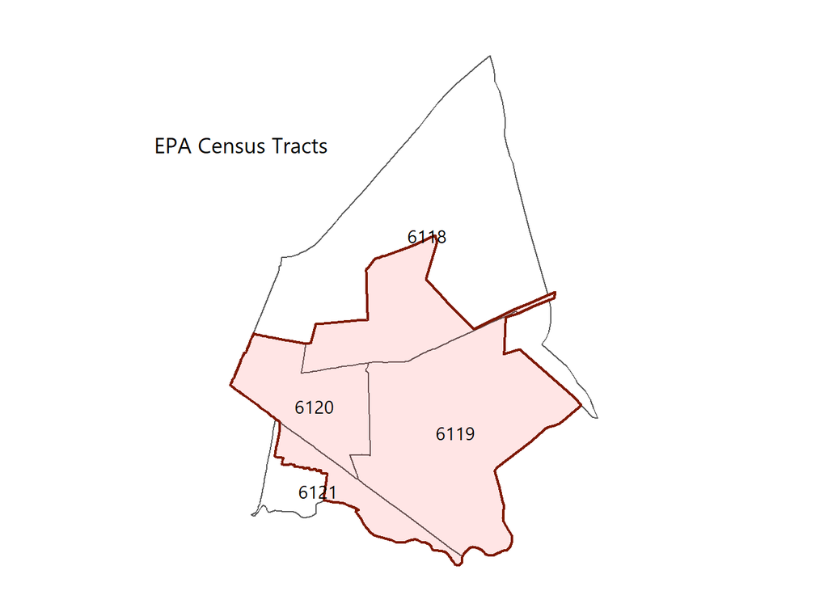

```r
## get EPA geometry
sanmateo <- tracts(state = 'CA', county = 'San Mateo')
epa <- places(state = 'CA') %>% filter(NAMELSAD == 'East Palo Alto city')

ggplot() +
  geom_sf(
    data = sanmateo[epa,] %>% filter(!(TRACTCE %in% c(990100, 611700, 611600, 613900))),
    fill = NA) +
  geom_sf(data = epa, color = roma.colors[1], fill = 'red', alpha = 0.1, size = 0.75) +
  geom_sf_text(
    data = sanmateo[epa,] %>% filter(!(TRACTCE %in% c(990100, 611700, 611600, 613900))),
    aes(label = NAME), family = 'Segoe UI') +
  ggtitle('EPA Census Tracts') +
  theme_void() +
  theme(
    text = element_text(family = 'Segoe UI'),
    plot.title = element_text(hjust = -0.25, vjust = -25))

mapview(epa)
```

```r
## subset to only claims in EPA
epa_policies <-
  policies %>%
  filter(
    censustract %in%
      (sanmateo[epa,] %>%
         filter(!(TRACTCE %in% c(990100, 611700, 611600, 613900))) %>%
         pull(GEOID) %>% toNumber)) %>%
  filter(
    reportedcity %in%
      c('E  PALO ALTO', 'E PALO ALTO', 'E.  PALO ALTO', 'E. PALO ALTO',
        'EAST PALO', 'EAST PALO ALTO', 'EAST PALTO ALTO'))
```

# 2 Number of Policies

```r
cat('Overall number of policies:\n')
comma(nrow(epa_policies))

cat('\nRange of policy start dates:\n')
range(epa_policies$policyeffectivedate)

cat('\nAnnual average number of policies:\n')
timediff <- toNumber(max(epa_policies$policyeffectivedate) - min(epa_policies$policyeffectivedate))/365
(nrow(epa_policies)/timediff) %>% comma(accuracy = 0.1)
```

```
## Overall number of policies:
## [1] "7,186"
##
## Range of policy start dates:
## [1] "2009-01-01 UTC" "2019-10-04 UTC"
##
## Annual average number of policies:
## [1] "667.7"
```

# 3 Flood Zone

```r
zonecode <- function(x) {
  if (grepl('A', x) | grepl('V', x)) { return('100')
  } else if (x %in% c('B', 'C')) { return('500')
  } else if (x %in% c('D', 'X')) { return('NO')
  } else if (x == 'OPEN WATER') { return('WATER')
  } else return(NA)
}
epa_policies %>%
  mutate(floodplain = factor(map_chr(.x = floodzone, .f = ~zonecode(.x)))) %>%
  pull(floodplain) %>%
  table %>% as.data.frame %>% setNames(c('val', 'freq')) %>%
  mutate(code = c('100-Year', '500-Year', 'Outside')) %>%
  mutate(pct = freq/sum(freq)) %>%
  dplyr::select(code, freq, pct) %>%
  gt %>%
  fmt_markdown(code) %>%
  fmt_number(freq, decimals = 0) %>%
  fmt_percent(pct) %>%
  cols_label(code = 'Flood Zone', freq = 'Number of Policies', pct = 'Percent of Policies') %>%
  tab_header('NFHL Status')
```

NFHL Status

| Flood Zone | Number of Policies | Percent of Policies |
| --- | --- | --- |
| 100-Year | 6,388 | 88.90% |
| 500-Year | 143 | 1.99% |
| Outside | 655 | 9.11% |

# 4 Basement Type

```r
epa_policies %>%
  pull(basementenclosurecrawlspace) %>%
  table %>% as.data.frame %>% setNames(c('val', 'freq')) %>%
  mutate(
    code = c(
      'No Basement',
      'Finished Basement',
      'Unfinished Basement',
      'Crawlspace',
      'Subgrade Crawlspace')) %>%
  mutate(pct = freq/sum(freq)) %>%
  select(code, freq, pct) %>%
  gt %>%
  fmt_markdown(code) %>%
  fmt_number(freq, decimals = 0) %>%
  fmt_percent(pct) %>%
  cols_label(code = 'Category', freq = 'Number of Policies', pct = 'Percent of Policies') %>%
  tab_header('Basement Type')
```

Basement Type

| Category | Number of Policies | Percent of Policies |
| --- | --- | --- |
| No Basement | 6,027 | 83.87% |
| Finished Basement | 27 | 0.38% |
| Unfinished Basement | 339 | 4.72% |
| Crawlspace | 377 | 5.25% |
| Subgrade Crawlspace | 416 | 5.79% |

# 5 Number of Floors

```r
epa_policies %>%
  pull(numberoffloorsintheinsuredbuilding) %>%
  table %>% as.data.frame %>% setNames(c('val', 'freq')) %>%
  mutate(code = c('1 Story', '2 Story', '3+ Stories', 'Split-Level')) %>%
  mutate(pct = freq/sum(freq)) %>%
  select(code, freq, pct) %>%
  gt %>%
  fmt_markdown(code) %>%
  fmt_number(freq, decimals = 0) %>%
  fmt_percent(pct) %>%
  cols_label(code = 'Category', freq = 'Number of Policies', pct = 'Percent of Policies') %>%
  tab_header('Number of Floors')
```

Number of Floors

| Category | Number of Policies | Percent of Policies |
| --- | --- | --- |
| 1 Story | 5,323 | 74.07% |
| 2 Story | 1,752 | 24.38% |
| 3+ Stories | 77 | 1.07% |
| Split-Level | 34 | 0.47% |

# 6 Building Construction Year

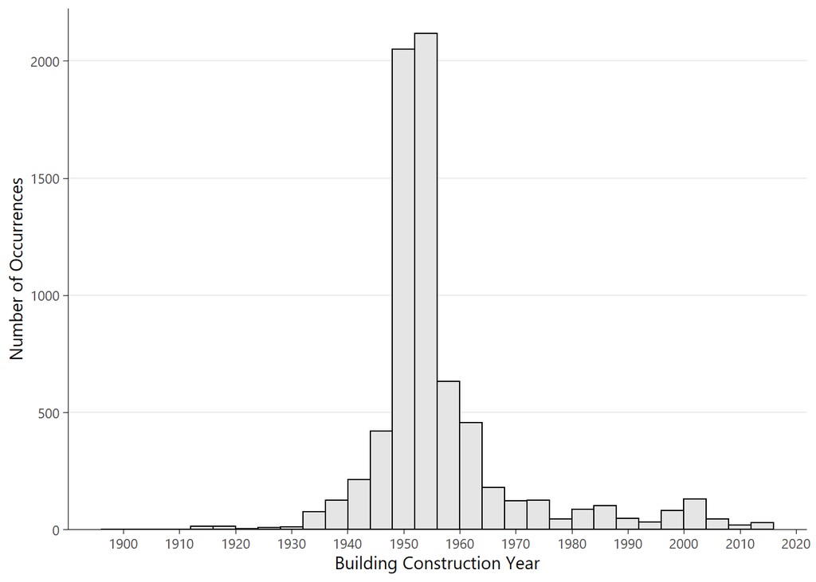

```r
ggplot(epa_policies) +
  geom_histogram(aes(x = as.Date(originalconstructiondate)), fill = 'grey90', color = 'black') +
  scale_x_date(
    'Building Construction Year',
    breaks = seq(ymd('1900-01-01'), ymd('2020-12-31'), '10 years'),
    date_labels = '%Y') +
  scale_y_origin('Number of Occurrences') +
  theme(panel.grid.major.y = element_line())
```

# 7 Elevated Building Indicator

An elevated building is a no-basement building that was constructed so as to meet the following criteria:

1. The top of the elevated floor (all A zones) or the bottom of the lowest horizontal structural member of the lowest floor (all V zones) is above ground level.
2. The building is adequately anchored.
3. The method of elevation is pilings, columns (posts and piers), shear walls (not in V zones), or solid foundation perimeter walls (not in V zones).

```r
epa_policies %>%
  pull(elevationbuildingindicator) %>%
  table %>% as.data.frame %>% setNames(c('val', 'freq')) %>%
  mutate(pct = freq/sum(freq)) %>%
  select(val, freq, pct) %>%
  gt %>%
  fmt_markdown(val) %>%
  fmt_number(freq, decimals = 0) %>%
  fmt_percent(pct) %>%
  cols_label(val = 'Elevated?', freq = 'Number of Policies', pct = 'Percent of Policies') %>%
  tab_header('Elevated Buildings')
```

Elevated Buildings

| Elevated? | Number of Policies | Percent of Policies |
| --- | --- | --- |
| FALSE | 5,821 | 81.00% |
| TRUE | 1,365 | 19.00% |

# 8 Primary Residence Indicator

A single-family dwelling/condominium unit qualifies as the primary residence of the insured provided that, at the time of loss, the named insured or the named insured’s spouse has lived in the dwelling for either (1) 80 percent of the 365 days immediately preceding the loss, or (2) 80 percent of the period of ownership of the insured dwelling, if ownership is less than 365 days.

Effective June 1, 2014, the NFIP defines primary residence to be a building that will be lived in by the insured or the insured’s spouse for more than 50 percent of the 365 days following the policy effective date.

```r
epa_policies %>%
  pull(primaryresidenceindicator) %>%
  table %>% as.data.frame %>% setNames(c('val', 'freq')) %>%
  mutate(pct = freq/sum(freq)) %>%
  select(val, freq, pct) %>%
  gt %>%
  fmt_markdown(val) %>%
  fmt_number(freq, decimals = 0) %>%
  fmt_percent(pct) %>%
  cols_label(val = 'Primary Residence?', freq = 'Number of Policies', pct = 'Percent of Policies') %>%
  tab_header('Primary Residence Indicator')
```

Primary Residence Indicator

| Primary Residence? | Number of Policies | Percent of Policies |
| --- | --- | --- |
| FALSE | 2,057 | 28.63% |
| TRUE | 5,129 | 71.37% |

# 9 Policy Deductible

```r
deductible <- function(x) {
  case_when(
    x == '0' ~ '$500',
    x == '1' ~ '$1,000',
    x == '2' ~ '$2,000',
    x == '3' ~ '$3,000',
    x == '4' ~ '$4,000',
    x == '5' ~ '$5,000',
    x == '9' ~ '$750',
    x == 'A' ~ '$10,000',
    x == 'B' ~ '$15,000',
    x == 'C' ~ '$20,000',
    x == 'D' ~ '$25,000',
    x == 'E' ~ '$50,000',
    x == 'F' ~ '$1,250',
    x == 'G' ~ '$1,500')
}
factorize = function(x) {
  factor(x, levels = rev(c('$500', '$750', '$1,000', '$1,250', '$1,500', '$2,000', '$3,000', '$4,000', '$5,000', '$10,000', '$15,000', '$20,000', '$25,000', '$50,000')))
}

temp <- epa_policies %>%
  mutate(
    building_deductible = deductible(deductibleamountinbuildingcoverage),
    contents_deductible = deductible(deductibleamountincontentscoverage)) %>%
  mutate(
    building_deductible = factorize(building_deductible),
    contents_deductible = factorize(contents_deductible))
```

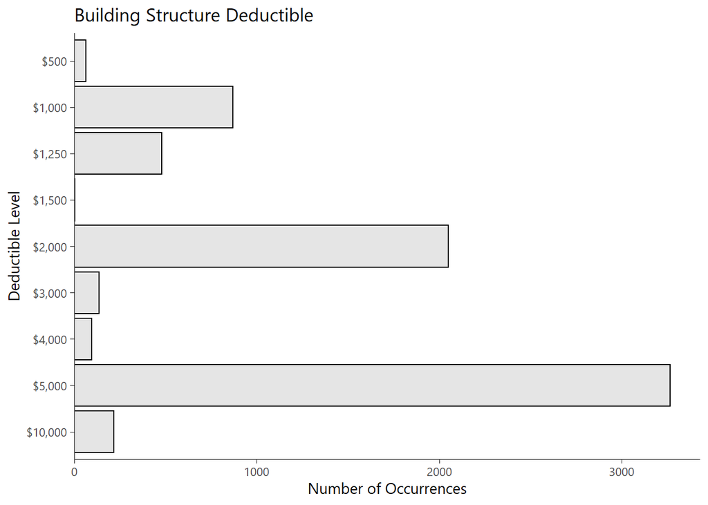

```r
ggplot(temp) +
  geom_bar(aes(x = building_deductible), color = 'black', fill = 'grey90') +
  coord_flip() +
  ggtitle('Building Structure Deductible') +
  scale_x_discrete('Deductible Level') +
  scale_y_origin('Number of Occurrences')
```

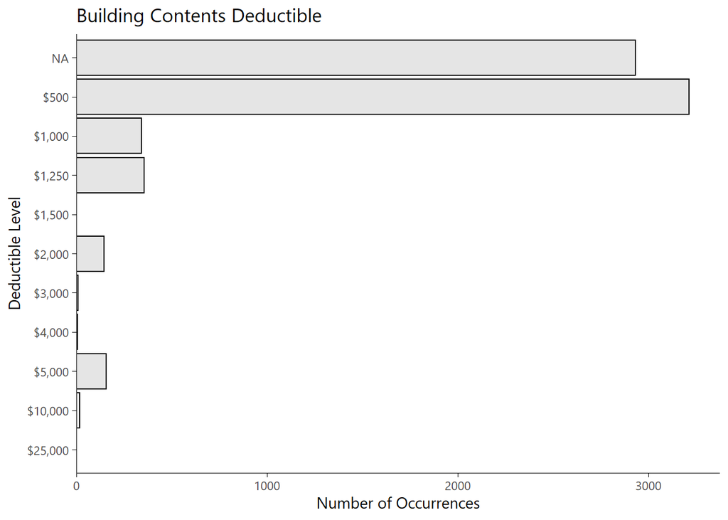

```r
ggplot(temp) +
  geom_bar(aes(x = contents_deductible), color = 'black', fill = 'grey90') +
  coord_flip() +
  ggtitle('Building Contents Deductible') +
  scale_x_discrete('Deductible Level') +
  scale_y_origin('Number of Occurrences')
```

```r
temp %>%
  mutate(building_deductible = factor(building_deductible, levels = rev(levels(building_deductible)))) %>%
  count(building_deductible) %>%
  mutate(pct = n/sum(n)) %>%
  gt %>%
  fmt_markdown(building_deductible) %>%
  fmt_number(n, decimals = 0) %>%
  fmt_percent(pct) %>%
  cols_label(building_deductible = 'Deductible', n = 'Number of Policies', pct = 'Percent of Policies') %>%
  tab_header('Building Deductible Distribution')
```

Building Deductible Distribution

| Deductible | Number of Policies | Percent of Policies |
| --- | --- | --- |
| $500 | 64 | 0.89% |
| $1,000 | 869 | 12.09% |
| $1,250 | 481 | 6.69% |
| $1,500 | 4 | 0.06% |
| $2,000 | 2,050 | 28.53% |
| $3,000 | 138 | 1.92% |
| $4,000 | 97 | 1.35% |
| $5,000 | 3,266 | 45.45% |
| $10,000 | 217 | 3.02% |

```r
temp %>%
  mutate(
    contents_deductible =
      ifelse(is.na(contents_deductible), '$0', paste(contents_deductible)) %>%
      factor(levels = c('$0', rev(levels(building_deductible))))) %>%
  count(contents_deductible) %>%
  mutate(pct = n/sum(n)) %>%
  gt %>%
  fmt_markdown(contents_deductible) %>%
  fmt_number(n, decimals = 0) %>%
  fmt_percent(pct) %>%
  cols_label(contents_deductible = 'Deductible', n = 'Number of Policies', pct = 'Percent of Policies') %>%
  tab_header('Contents Deductible Distribution')
```

Contents Deductible Distribution

| Deductible | Number of Policies | Percent of Policies |
| --- | --- | --- |
| $0 | 2,933 | 40.82% |
| $500 | 3,214 | 44.73% |
| $1,000 | 342 | 4.76% |
| $1,250 | 355 | 4.94% |
| $1,500 | 2 | 0.03% |
| $2,000 | 146 | 2.03% |
| $3,000 | 11 | 0.15% |
| $4,000 | 6 | 0.08% |
| $5,000 | 157 | 2.18% |
| $10,000 | 18 | 0.25% |
| $25,000 | 2 | 0.03% |

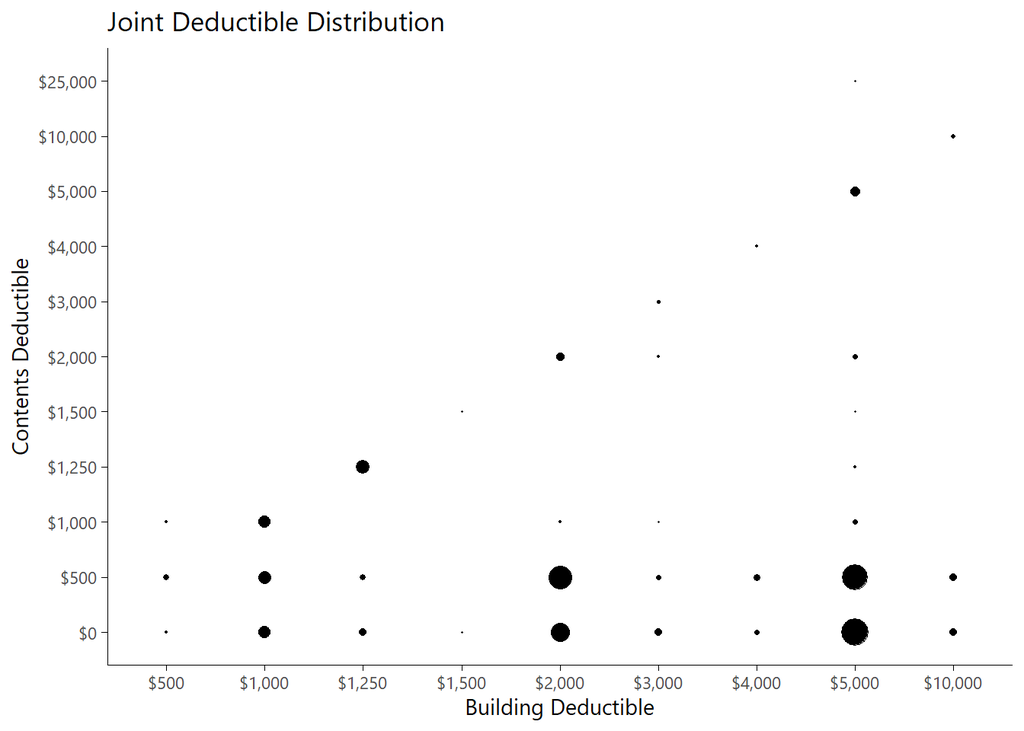

```r
temp %>%
  count(building_deductible, contents_deductible, name = 'Number') %>%
  mutate(
    contents_deductible =
      ifelse(is.na(contents_deductible), '$0', paste(contents_deductible))) %>%
  mutate(
    building_deductible =
      factor(building_deductible, levels = rev(levels(building_deductible))),
    contents_deductible =
      factor(contents_deductible, levels = c('$0', levels(building_deductible)))) %>%
  ggplot() +
  geom_point(
    aes(x = building_deductible, y = contents_deductible, size = Number),
    show.legend = FALSE) +
  scale_size_area() +
  ggtitle('Joint Deductible Distribution') +
  labs(x = 'Building Deductible', y = 'Contents Deductible')
```